# `pandas`

- Etymology: **pan**el **da**ta
- Written by [Wes McKinney](http://wesmckinney.com/)
- DataFrames for Python
- Read/Write for many formats
- Very efficient operations (much more efficient than plain python)
- Database-like API
- Very popular amongst Data Scientists

## Pandas - Why Python is booming

[figure not shown]

[Stackoverflow Blog: Why is Python Growing So Quickly?](https://stackoverflow.blog/2017/09/14/python-growing-quickly/)

# Pandas Data Structures

- `Series`: one-dimensional array of indexed data (*think: column of a table/database*)
- `DataFrame`: table (*think: data base*)

# The Pandas Series Object

Pandas `Series`: one-dimensional array of indexed data

```python
import numpy as np
import pandas as pd
import warnings
warnings.filterwarnings("ignore", message="numpy.dtype size changed")
warnings.filterwarnings("ignore", message="numpy.ufunc size changed")

# create a pandas Series
series_a = pd.Series([0.25, 0.5, 0.75, 1.0])
series_a
```

```
0    0.25
1    0.50
2    0.75
3    1.00
dtype: float64
```

```python
series_a.index
```

```
RangeIndex(start=0, stop=4, step=1)
```

```python
series_a.values
```

```
array([0.25, 0.5 , 0.75, 1.  ])
```

## Generating Pandas Series

Pandas `Series` can be created from most python collections.

This also means that they support all content types that python collections support.

```python
# a list
list_a = ['one','two','three']

series_b = pd.Series(list_a)
series_b
```

```
0      one
1      two
2    three
dtype: object
```

```python
# a list with indices
list_a = ['one','two','three']
list_b = ['index_one','index_two','index_three']

series_c = pd.Series(data=list_a, index=list_b)
series_c
```

```
index_one        one
index_two        two
index_three    three
dtype: object
```

```python
# creating Series with same value
pd.Series(5, index=[100, 200, 300])
```

```
100    5
200    5
300    5
dtype: int64
```

## Why is this helpful?

There are many reasons why these indexed structures are helpful. Most of them are related to speed. But many are related to convenience:

```python
fruits = pd.Series([1,0,2,2,9], index=['apples','oranges','bananas','lemons', 'avocado'])
more_fruits = pd.Series([1,0,1,5], index=['lemons','oranges','apples', 'bananas'])

fruits + more_fruits
```

```
apples     2.0
avocado    NaN
bananas    7.0
lemons     3.0
oranges    0.0
dtype: float64
```

```python
fruits
```

```
apples     1
oranges    0
bananas    2
lemons     2
avocado    9
dtype: int64
```

```python
more_fruits
```

```
lemons     1
oranges    0
apples     1
bananas    5
dtype: int64
```

## Some More Examples

```python
berlin_population_dict = {
 '1917': 1681916,
 '1919': 1902509,
 '1925': 4024286,
 '1933': 4242501,
 '1939': 4338756,
 '1945': 2807405,
 '1946': 3170832,
 '1950': 3336026,
 '1960': 3274016,
 '1970': 3208719,
 '1980': 3048759,
 '1990': 3433695,
 '2000': 3382169,
 '2005': 3394000,
 '2010': 3460725}

population = pd.Series(berlin_population_dict)
```

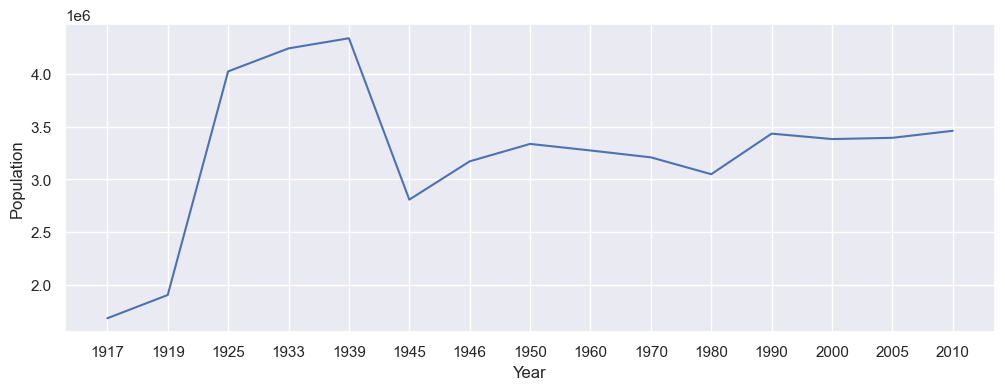

```python
import matplotlib.pyplot as plt
import seaborn; seaborn.set()  # set plot style
plt.figure(figsize=[12,4])
plt.plot(population)
plt.ylabel("Population")
plt.xlabel("Year")
plt.show()
```

## Indexing Pandas Series

```python
population.name = 'Population'
population.index.name = 'Year'
# note that the indices are strings
population
```

```
Year
1917    1681916
1919    1902509
1925    4024286
1933    4242501
1939    4338756
1945    2807405
1946    3170832
1950    3336026
1960    3274016
1970    3208719
1980    3048759
1990    3433695
2000    3382169
2005    3394000
2010    3460725
Name: Population, dtype: int64
```

```python
population['1917']
```

```
1681916
```

```python
population[['1917','1925','1945','2010']]
```

```
Year
1917    1681916
1925    4024286
1945    2807405
2010    3460725
Name: Population, dtype: int64
```

```python
population['1925':'1950']
```

```
Year
1925    4024286
1933    4242501
1939    4338756
1945    2807405
1946    3170832
1950    3336026
Name: Population, dtype: int64
```

```python
population > 3e6
```

```
Year
1917    False
1919    False
1925     True
1933     True
1939     True
1945    False
1946     True
1950     True
1960     True
1970     True
1980     True
1990     True
2000     True
2005     True
2010     True
Name: Population, dtype: bool
```

```python
population[population > 3e6]
```

```
Year
1925    4024286
1933    4242501
1939    4338756
1946    3170832
1950    3336026
1960    3274016
1970    3208719
1980    3048759
1990    3433695
2000    3382169
2005    3394000
2010    3460725
Name: Population, dtype: int64
```

```python
population[population==1681916]
```

```
Year
1917    1681916
Name: Population, dtype: int64
```

```python
population[(population==1681916) | (population==3460725)]
```

```
Year
1917    1681916
2010    3460725
Name: Population, dtype: int64
```

## Explicit and Positional Indexing

- Pandas objects can be indexed in different ways:
- explicit indices: what you define as index
- positional index: the row number
- Depending on how you access values in a `pandas` object, explicit or positional indexing is used.
- To avoid confusion, specify the type of indexing with `loc` (explicit indexing) or `iloc` (positional indexing)

```python
data = pd.Series(['a', 'b', 'c'], index=[1, 3, 5])
# explicit index when indexing
data[1]
```

```
'a'
```

```python
data = pd.Series(['a', 'b', 'c'], index=[1, 3, 5])
# explicit index when fancy-indexing
data[[1,3]]
```

```
1    a
3    b
dtype: object
```

```python
data = pd.Series(['a', 'b', 'c'], index=[1, 3, 5])
# positional index when slicing
data[1:3]
```

```
3    b
5    c
dtype: object
```

```python
data = pd.Series(['a', 'b', 'c'], index=['1', '3', '5'])
# positional index when actual index is not integer valued
data[1]
```

```
'b'
```

### Explicit Indexing with `loc`

```python
data = pd.Series(['a', 'b', 'c'], index=[1, 3, 5])
data.loc[1]
```

```
'a'
```

```python
data = pd.Series(['a', 'b', 'c'], index=[1, 3, 5])
#  loc for explicit indexing
data.loc[1:3]
```

```
1    a
3    b
dtype: object
```

### Positional Indexing with `iloc`

```python
data = pd.Series(['a', 'b', 'c'], index=[1, 3, 5])
data.iloc[1]
```

```
'b'
```

```python
data = pd.Series(['a', 'b', 'c'], index=[1, 3, 5])
data.iloc[1:3]
```

```
3    b
5    c
dtype: object
```

## Operations on Pandas Series

- Efficient arithmetic and aggregation operations
- Compatible with `numpy`

```python
population_in_millions = population / 1e6
population_in_millions
```

```
Year
1917    1.681916
1919    1.902509
1925    4.024286
1933    4.242501
1939    4.338756
1945    2.807405
1946    3.170832
1950    3.336026
1960    3.274016
1970    3.208719
1980    3.048759
1990    3.433695
2000    3.382169
2005    3.394000
2010    3.460725
Name: Population, dtype: float64
```

```python
# histograms
population_in_millions.value_counts()
```

```
Population
1.681916    1
1.902509    1
4.024286    1
4.242501    1
4.338756    1
2.807405    1
3.170832    1
3.336026    1
3.274016    1
3.208719    1
3.048759    1
3.433695    1
3.382169    1
3.394000    1
3.460725    1
Name: count, dtype: int64
```

```python
# sorting
population.sort_values()
```

```
Year
1917    1681916
1919    1902509
1945    2807405
1980    3048759
1946    3170832
1970    3208719
1960    3274016
1950    3336026
2000    3382169
2005    3394000
1990    3433695
2010    3460725
1925    4024286
1933    4242501
1939    4338756
Name: Population, dtype: int64
```

```python
# basic stats
population.describe()
```

```
count    1.500000e+01
mean     3.247088e+06
std      7.276748e+05
min      1.681916e+06
25%      3.109796e+06
50%      3.336026e+06
75%      3.447210e+06
max      4.338756e+06
Name: Population, dtype: float64
```

## Applying Arbitrary Functions

```python
# apply custom functions

def some_function(v):
    '''
    Divides number by a million and returns its integer representation
    '''
    return int(v / 1e6)

some_function(35 * 1e6)
```

```
35
```

```python
population.apply(some_function)
```

```
Year
1917    1
1919    1
1925    4
1933    4
1939    4
1945    2
1946    3
1950    3
1960    3
1970    3
1980    3
1990    3
2000    3
2005    3
2010    3
Name: Population, dtype: int64
```

```python
s = pd.Series(range(int(1e6)))
%timeit s.apply(some_function)
```

```
280 ms ± 16.3 ms per loop (mean ± std. dev. of 7 runs, 1 loop each)
```

```python
%timeit (s / 1e6).astype(int)
```

```
1.25 ms ± 26.8 µs per loop (mean ± std. dev. of 7 runs, 1,000 loops each)
```

# Missing Values

There are three main options how to deal with missing values:

- drop rows with missing values
- replace missing values with placeholder symbol
- impute missing values with some ML model

```python
berlin_population_dict = {
 '1945': 2807405,
 '1950': 3336026,
 '1955': None,
 '1960': 3274016,
 '1965': np.nan,
 '1970': 3208719}

population_w_nans = pd.Series(berlin_population_dict)
population_w_nans
```

```
1945    2807405.0
1950    3336026.0
1955          NaN
1960    3274016.0
1965          NaN
1970    3208719.0
dtype: float64
```

## Dropping rows

```python
population_w_nans.isnull()
```

```
1945    False
1950    False
1955     True
1960    False
1965     True
1970    False
dtype: bool
```

```python
population_w_nans[~population_w_nans.isnull()]
```

```
1945    2807405.0
1950    3336026.0
1960    3274016.0
1970    3208719.0
dtype: float64
```

```python
population_w_nans.dropna()
```

```
1945    2807405.0
1950    3336026.0
1960    3274016.0
1970    3208719.0
dtype: float64
```

# The Pandas DataFrame Object

Pandas `Dataframe`: **a table** (or DataBase - i.e. one or more Series concatenated)

## Generating Pandas DataFrames

```python
some_numpy_array = np.arange(9).reshape((3, 3))
some_numpy_array
```

```
array([[0, 1, 2],
       [3, 4, 5],
       [6, 7, 8]])
```

```python
df = pd.DataFrame(some_numpy_array,
                        index=['a', 'c', 'd'],
                        columns=['Ohio', 'Texas', 'California'])
df
```

|  | Ohio | Texas | California |
| --- | --- | --- | --- |
| a | 0 | 1 | 2 |
| c | 3 | 4 | 5 |
| d | 6 | 7 | 8 |

### Pandas DataFrame Constructors

Type

Notes

2D ndarray

A matrix of data, passing optional row and column labels

dict of arrays, lists, or tuples

Each sequence becomes a column in the DataFrame; all sequences must be the same length

NumPy structured/record array

Treated as the *dict of arrays* case

dict of Series

Each value becomes a column

dict of dicts

Each inner dict becomes a column

List of dicts or Series

Each item becomes a row in the DataFrame

List of lists or tuples

Treated as the “2D ndarray” case

Another DataFrame

The DataFrame’s indexes are used unless different ones are passed

NumPy MaskedArray

Like the “2D ndarray” case except masked values become NA/missing in the DataFrame result

```python
# a DataFrame from a csv file
import os
df_from_csv = pd.read_csv(os.path.join("data","berlin_population.csv"))
```

### Pandas DataFrame IO

| Format Type | Data Description | Reader | Writer |
| --- | --- | --- | --- |
| text | CSV | read_csv | to_csv |
| text | JSON | read_json | to_json |
| text | HTML | read_html | to_html |
| text | Local clipboard | read_clipboard | to_clipboard |
| binary | MS Excel | read_excel | to_excel |
| binary | HDF5 Format | read_hdf | to_hdf |
| binary | Feather Format | read_feather | to_feather |
| binary | Parquet Format | read_parquet | to_parquet |
| binary | Msgpack | read_msgpack | to_msgpack |
| binary | Stata | read_stata | to_stata |
| binary | SAS | read_sas |  |
| binary | Python Pickle Format | read_pickle | to_pickle |
| SQL | SQL | read_sql | to_sql |
| SQL | Google Big Query | read_gbq | to_gbq |

## Accessing Values in Pandas Data Frames

```python
# some data
berlin_population_by_borough = {
  'Area in km²': {
    'Charlottenburg-Wilmersdorf': 64.72,
    'Friedrichshain-Kreuzberg': 20.16,
    'Lichtenberg': 52.29,
    'Marzahn-Hellersdorf': 61.74,
    'Mitte': 39.47,
    'Neukölln': 44.93,
    'Pankow': 103.01,
    'Spandau': 91.91,
    'Steglitz-Zehlendorf': 102.5,
    'Tempelhof-Schöneberg': 53.09,
    'Treptow-Köpenick': 168.42},
 'Population 30 September 2010': {
    'Charlottenburg-Wilmersdorf': 320014,
    'Friedrichshain-Kreuzberg': 268831,
    'Lichtenberg': 259881,
    'Marzahn-Hellersdorf': 248264,
    'Mitte': 332100,
    'Neukölln': 310283,
    'Pankow': 368956,
    'Spandau': 225420,
    'Steglitz-Zehlendorf': 293989,
    'Tempelhof-Schöneberg': 335060,
    'Treptow-Köpenick': 241335}}
```

```python
# a DataFrame from a dictionary of dictionaries
df = pd.DataFrame(berlin_population_by_borough)
df
```

|  | Area in km² | Population 30 September 2010 |
| --- | --- | --- |
| Charlottenburg-Wilmersdorf | 64.72 | 320014 |
| Friedrichshain-Kreuzberg | 20.16 | 268831 |
| Lichtenberg | 52.29 | 259881 |
| Marzahn-Hellersdorf | 61.74 | 248264 |
| Mitte | 39.47 | 332100 |
| Neukölln | 44.93 | 310283 |
| Pankow | 103.01 | 368956 |
| Spandau | 91.91 | 225420 |
| Steglitz-Zehlendorf | 102.50 | 293989 |
| Tempelhof-Schöneberg | 53.09 | 335060 |
| Treptow-Köpenick | 168.42 | 241335 |

```python
# like Series (and tables in DBs) DataFrames have indices
df.index
```

```
Index(['Charlottenburg-Wilmersdorf', 'Friedrichshain-Kreuzberg', 'Lichtenberg',
       'Marzahn-Hellersdorf', 'Mitte', 'Neukölln', 'Pankow', 'Spandau',
       'Steglitz-Zehlendorf', 'Tempelhof-Schöneberg', 'Treptow-Köpenick'],
      dtype='object')
```

```python
# Accessing by row and column index
df.loc['Friedrichshain-Kreuzberg','Area in km²']
```

```
20.16
```

```python
# Accessing an entire column
df.loc[:,'Area in km²']
```

```
Charlottenburg-Wilmersdorf     64.72
Friedrichshain-Kreuzberg       20.16
Lichtenberg                    52.29
Marzahn-Hellersdorf            61.74
Mitte                          39.47
Neukölln                       44.93
Pankow                        103.01
Spandau                        91.91
Steglitz-Zehlendorf           102.50
Tempelhof-Schöneberg           53.09
Treptow-Köpenick              168.42
Name: Area in km², dtype: float64
```

```python
# Accessing an entire column (= Series)
df['Area in km²']
```

```
Charlottenburg-Wilmersdorf     64.72
Friedrichshain-Kreuzberg       20.16
Lichtenberg                    52.29
Marzahn-Hellersdorf            61.74
Mitte                          39.47
Neukölln                       44.93
Pankow                        103.01
Spandau                        91.91
Steglitz-Zehlendorf           102.50
Tempelhof-Schöneberg           53.09
Treptow-Köpenick              168.42
Name: Area in km², dtype: float64
```

```python
# boolean indexing
df['Population 30 September 2010'] > 3e5
```

```
Charlottenburg-Wilmersdorf     True
Friedrichshain-Kreuzberg      False
Lichtenberg                   False
Marzahn-Hellersdorf           False
Mitte                          True
Neukölln                       True
Pankow                         True
Spandau                       False
Steglitz-Zehlendorf           False
Tempelhof-Schöneberg           True
Treptow-Köpenick              False
Name: Population 30 September 2010, dtype: bool
```

```python
# boolean indexing
df[df['Population 30 September 2010'] > 3e5]
```

|  | Area in km² | Population 30 September 2010 |
| --- | --- | --- |
| Charlottenburg-Wilmersdorf | 64.72 | 320014 |
| Mitte | 39.47 | 332100 |
| Neukölln | 44.93 | 310283 |
| Pankow | 103.01 | 368956 |
| Tempelhof-Schöneberg | 53.09 | 335060 |

```python
# boolean row indexing with column indexing
df.loc[df['Population 30 September 2010'] > 3e5,'Population 30 September 2010']
```

```
Charlottenburg-Wilmersdorf    320014
Mitte                         332100
Neukölln                      310283
Pankow                        368956
Tempelhof-Schöneberg          335060
Name: Population 30 September 2010, dtype: int64
```

## Operations on Pandas Data Frames

- All Series operations work on DataFrame columns
- DataFrames support all standard DB operations and more

```python
df['Density'] = df['Population 30 September 2010'] / df['Area in km²']
df = df.sort_values(by=['Density'])
df
```

|  | Area in km² | Population 30 September 2010 | Density |
| --- | --- | --- | --- |
| Treptow-Köpenick | 168.42 | 241335 | 1432.935518 |
| Spandau | 91.91 | 225420 | 2452.616690 |
| Steglitz-Zehlendorf | 102.50 | 293989 | 2868.185366 |
| Pankow | 103.01 | 368956 | 3581.749345 |
| Marzahn-Hellersdorf | 61.74 | 248264 | 4021.120829 |
| Charlottenburg-Wilmersdorf | 64.72 | 320014 | 4944.592089 |
| Lichtenberg | 52.29 | 259881 | 4969.994263 |
| Tempelhof-Schöneberg | 53.09 | 335060 | 6311.169712 |
| Neukölln | 44.93 | 310283 | 6905.920320 |
| Mitte | 39.47 | 332100 | 8413.985305 |
| Friedrichshain-Kreuzberg | 20.16 | 268831 | 13334.871032 |

## Database style joins with pandas

```python
df1 = pd.DataFrame({'key': ['b', 'b', 'a', 'c', 'a', 'a', 'b'], 'data1': range(7)})
df1
```

|  | key | data1 |
| --- | --- | --- |
| 0 | b | 0 |
| 1 | b | 1 |
| 2 | a | 2 |
| 3 | c | 3 |
| 4 | a | 4 |
| 5 | a | 5 |
| 6 | b | 6 |

```python
df2 = pd.DataFrame({'key': ['a', 'b', 'd'], 'data2': range(3)})
df2
```

|  | key | data2 |
| --- | --- | --- |
| 0 | a | 0 |
| 1 | b | 1 |
| 2 | d | 2 |

### Inner join

```python
pd.merge(df1, df2, on='key')
```

|  | key | data1 | data2 |
| --- | --- | --- | --- |
| 0 | b | 0 | 1 |
| 1 | b | 1 | 1 |
| 2 | a | 2 | 0 |
| 3 | a | 4 | 0 |
| 4 | a | 5 | 0 |
| 5 | b | 6 | 1 |

### Outer join

```python
pd.merge(df1, df2, on='key', how='outer')
```

|  | key | data1 | data2 |
| --- | --- | --- | --- |
| 0 | a | 2.0 | 0.0 |
| 1 | a | 4.0 | 0.0 |
| 2 | a | 5.0 | 0.0 |
| 3 | b | 0.0 | 1.0 |
| 4 | b | 1.0 | 1.0 |
| 5 | b | 6.0 | 1.0 |
| 6 | c | 3.0 | NaN |
| 7 | d | NaN | 2.0 |

## Concatenation

Remember numpy array concatenation

```python
import numpy as np
arr = np.arange(12).reshape((3, 4))
arr
```

```
array([[ 0,  1,  2,  3],
       [ 4,  5,  6,  7],
       [ 8,  9, 10, 11]])
```

```python
np.concatenate([arr, arr], axis=1)
```

```
array([[ 0,  1,  2,  3,  0,  1,  2,  3],
       [ 4,  5,  6,  7,  4,  5,  6,  7],
       [ 8,  9, 10, 11,  8,  9, 10, 11]])
```

```python
np.concatenate([arr, arr], axis=0)
```

```
array([[ 0,  1,  2,  3],
       [ 4,  5,  6,  7],
       [ 8,  9, 10, 11],
       [ 0,  1,  2,  3],
       [ 4,  5,  6,  7],
       [ 8,  9, 10, 11]])
```

## Concatenation with Pandas

```python
s1 = pd.Series([0, 1], index=['a', 'b'])
s1
```

```
a    0
b    1
dtype: int64
```

```python
s2 = pd.Series([2, 3, 4], index=['c', 'd', 'e'])
s2
```

```
c    2
d    3
e    4
dtype: int64
```

```python
s3 = pd.Series([5, 6], index=['f', 'g'])
pd.concat([s1, s2, s3])
```

```
a    0
b    1
c    2
d    3
e    4
f    5
g    6
dtype: int64
```

```python
pd.concat([s1, s2, s3], axis=1, sort=True)
```

|  | 0 | 1 | 2 |
| --- | --- | --- | --- |
| a | 0.0 | NaN | NaN |
| b | 1.0 | NaN | NaN |
| c | NaN | 2.0 | NaN |
| d | NaN | 3.0 | NaN |
| e | NaN | 4.0 | NaN |
| f | NaN | NaN | 5.0 |
| g | NaN | NaN | 6.0 |

## Group-by and Aggregations

Aka split-apply-combine

[figure not shown]

```python
df = pd.DataFrame({ 'key1' : ['a', 'a', 'b', 'b', 'a'],
                    'key2' : ['one', 'two', 'one', 'two', 'one'],
                    'data1' : np.random.randn(5),
                    'data2' : np.random.randn(5)})
df
```

|  | key1 | key2 | data1 | data2 |
| --- | --- | --- | --- | --- |
| 0 | a | one | 1.120271 | -1.981180 |
| 1 | a | two | 0.822986 | -1.014660 |
| 2 | b | one | 0.276778 | 0.806258 |
| 3 | b | two | -0.211560 | 0.885226 |
| 4 | a | one | -0.216526 | 0.530888 |

```python
grouped = df['data1'].groupby(df['key1'])
grouped
```

```
<pandas.core.groupby.generic.SeriesGroupBy object at 0x7fc5f92a96d0>
```

```python
grouped.mean()
```

```
key1
a    0.575577
b    0.032609
Name: data1, dtype: float64
```

```python
grouped.max()
```

```
key1
a    1.120271
b    0.276778
Name: data1, dtype: float64
```

```python
grouped.quantile(.9)
```

```
key1
a    1.060814
b    0.227944
Name: data1, dtype: float64
```

```python
df.groupby(['key1','key2'])['data1'].agg(['mean','sum']).rename(columns={'mean': 'my_mean', 'sum':'my_sum'})
```

| key1 | key2 | my_mean | my_sum |
| --- | --- | --- | --- |
| a | one | 0.451873 | 0.903745 |
|  | two | 0.822986 | 0.822986 |
| b | one | 0.276778 | 0.276778 |
|  | two | -0.211560 | -0.211560 |

### Iterating over groups

```python
for name, group in df.groupby('key1'):
    print(name)
    print(group)
```

```
a
  key1 key2     data1     data2
0    a  one  1.120271 -1.981180
1    a  two  0.822986 -1.014660
4    a  one -0.216526  0.530888
b
  key1 key2     data1     data2
2    b  one  0.276778  0.806258
3    b  two -0.211560  0.885226
```

```python
for (k1, k2), group in df.groupby(['key1', 'key2']):
    print((k1, k2))
    print(group)
```

```
('a', 'one')
  key1 key2     data1     data2
0    a  one  1.120271 -1.981180
4    a  one -0.216526  0.530888
('a', 'two')
  key1 key2     data1    data2
1    a  two  0.822986 -1.01466
('b', 'one')
  key1 key2     data1     data2
2    b  one  0.276778  0.806258
('b', 'two')
  key1 key2    data1     data2
3    b  two -0.21156  0.885226
```